# pipeRline script for Hemiptera metabarcoding analysis

Alexander Piper

21/09/2018

[figure not shown]

Piperline

# Introduction

This is version 0.2 of the PipeRline metabarcoding analysis workflow, as implemented for the analysis of the Hemiptera metabarcoding data for PBCRC Natural Dispersal project #2153

A typical metabarcoding analysis retains tens to hundreds of millions of reads following quality filtering, and assigning taxonomy to each read individually can be a computationally intensive and lengthy process, taking multiple days on powerful computing clusters. To alleviate this computational burden, sequence dereplication (Traditionally OTU clustering) used to collapse similar sequences into distinct subgroups, each with a single representative sequence and an associated abundance or read count, enabling rapid downstream analysis using the representative rather than the full dataset.

A challenge of many OTU methods is that memory requirements and running time scale quadratically with sequencing depth, because these methods rely on pairwise comparisons between all sequencing reads. This pipeline is instead based around the DADA2 package (https://benjjneb.github.io/dada2/index.html) to perform the majority of the sequence read processing. DADA2 breaks this quadratic scaling by **processing samples independently**. This is possible because DADA2 infers exact sequence variants, and exact sequences are consistent labels that can be directly compared across separately processed samples. This isn’t the case for OTUs, as the boundaries and membership of de novo OTUs depend on the rest of the dataset and the arbitrary clustering threshold chosen, and thus are only valid and consistent when all sequences are pooled together for OTU picking.

Separable sample processing allows DADA2’s running time to scale linearly in the number of samples, and its memory requirements to remain nearly flat. In addition, the most costly portion of the workflow is fully data parallelizable, and can be spread across non-interacting compute nodes such as the BASC system located at AgriBio.

For biosecurity, decisions are made on species level taxonomy. For metabarcoding, the assignment of Linnaean taxonomy (species, genus etc.) is conducted through an automated classification approach. The main challenges that automated taxonomic classification faces is that all reference databases are by nature incomplete, and may also contain mis-annotated sequences. This can cause two problems, firstly Over-classification, or when query sequences are incorrectly assigned to the wrong species-level taxonomy due to the absence of reference data which can potentially lead to incorrect classification of previously un-sequenced but probably innocuous taxa as a known pest, due to the pest having an existing DNA barcode. And secondly under-classifciation where the algorithm is too conservative and the query is not assigned to taxonomy, resulting in the potential to miss a serious pest

The PipeRline currently uses the RDP naive Bayesian classifier algorithm (as natively implementated in the DADA2 R Package) for assigning taxonomy. This classifier splits the query sequences into 8-mers and uses repeated random sampling of these 8-mers against the reference database to estimate the confidence of the query sequences inclusion into each taxonomic rank. In an ideal case, only a single possible taxonomic assignment will obtain a high level of probability, whereas alternate outcomes will obtain probabilities close to zero. In cases where there may be ambiguity due to imperfect reference data and multiple taxonomic outcomes obtain similar probabilities, the sequence may still be robustly assigned to a higher taxonomic rank (i.e. family), providing important information about sample composition and possible presence of novel taxa without over-classifying and producing false positives.

In the DADA2 package, the RDP classifier is called upon using the ‘assignTaxonomy’ function. This function takes as input a set of sequences to be classified and a training set of reference sequences with known taxonomy, and outputs taxonomic assignments with at least minBoot bootstrap confidence.

Importantly, while the RDP classifier will assign taxonomy across multiple ranks (e.g. Kingdom to Genus), it will not assign species level taxonomy to the sequences. DADA2 therefore implements a second method, assignSpecies that uses exact string matching against a reference database to assign Genus species binomials ONLY if it is an unambiguous match.

NOTE: This functionality was designed for 16s marker gene sequencing, where recent results indicate that exact matching (or 100% identity) with exact sequence variants is the only appropriate method for species-level assignment to high-throughput 16S amplicon data, however this is perhaps too conservative for the fast evolving COI gene. Therefore future versions of the PipeRline should explore alternative taxonomic assignment methods for species level taxonomy

## Reference Databases

the DADA2 creators maintain formatted reference databases for both Bacterial and Fungi classification: https://benjjneb.github.io/dada2/training.html however for COI you will need to use a custom database

For Kingdom to genus classification: assignTaxonomy(…) expects a training fasta file (or compressed fasta file) in which the taxonomy corresponding to each sequence is encoded in the id line in the following fashion (the second sequence is not assigned down to level 6):

```
>Level1;Level2;Level3;Level4;Level5;Level6;
ACCTAGAAAGTCGTAGATCGAAGTTGAAGCATCGCCCGATGATCGTCTGAAGCTGTAGCATGAGTCGATTTTCACATTCAGGGATACCATAGGATAC
>Level1;Level2;Level3;Level4;Level5;
CGCTAGAAAGTCGTAGAAGGCTCGGAGGTTTGAAGCATCGCCCGATGGGATCTCGTTGCTGTAGCATGAGTACGGACATTCAGGGATCATAGGATAC
```

For Species level classification: both assignSpecies(…) and addSpecies(…) expect the training data to be provided in the form of a fasta file (or compressed fasta file), with the id line formatted as follows:

```
> ID Genus species
ACCTAGAAAGTCGTAGATCGAAGTTGAAGCATCGCCCGATGATCGTCTGAAGCTGTAGCATGAGTCGATTTTCACATTCAGGGATACCATAGGATAC
> ID Genus species
CGCTAGAAAGTCGTAGAAGGCTCGGAGGTTTGAAGCATCGCCCGATGGGATCTCGTTGCTGTAGCATGAGTACGGACATTCAGGGATCATAGGATAC
```

Finally, following taxonomic assignment, both the sequence table and taxonomic table generated by DADA2 are passed to the Phyloseq package (https://joey711.github.io/phyloseq/) for further community analysis and visualisation of data. The phyloseq package is a tool to import, store, analyze, and graphically display complex phylogenetic sequencing data that has already been dereplicated into ESV’s along with associated sample data, phylogenetic tree, and/or taxonomic assignment of the ESV’s. The package leverages many of the tools available in R for ecology and phylogenetic analysis (vegan, ade4, ape, picante), while also using advanced/flexible graphic systems (ggplot2) to easily produce publication-quality graphics of complex phylogenetic data. phyloseq uses a specialized system of S4 classes to store all related phylogenetic sequencing data as single experiment-level object, making it easier to share data and reproduce analyses

NOTE: Currently the functionality to track the amount of reads making it through each stage is not working, job for next version

# Prior to analysis

The PipeRline workflow assumes that your sequencing data meets certain criteria:

1. Samples have been demultiplexed, i.e. split into individual per-sample fastq files.
   - This is normally handled by the Illumina software (MiSeq), or Tracie Webster (HiSeq).
2. For paired-end sequencing data, the forward and reverse fastq files contain reads in matched order.
3. Non-biological nucleotides have been removed, e.g. primers, adapters, linkers, etc.
   - The illumina adapters will normally be removed during demultiplexing, however primer sequences will remain in the reads and must be removed prior to use with the DADA2 algorithm

If you are using a gene such as COI that is not length variable you can use the trimLeft and TruncL function in the filter & Trim stage to remove remaining primers. However in this study there were 3 amplicons of different size generated in a multiplexed PCR, some of which were too short, and therefore contain 3’ primer sequences in addition to the 5’primer

Therefore, for this workflow we will be using an additional adapter trimming software BBDuk (Part of BBTools package https://jgi.doe.gov/data-and-tools/bbtools/) to trim the primers from our raw data files. “Duk” stands for Decontamination Using Kmers. BBDuk is capable of quality-trimming and filtering, adapter-trimming, contaminant-filtering via kmer matching.

## Primers:

```
Name                    Illumina overhang adapter           Primer sequences
Sterno18S_F2_tail       ACACTCTTTCCCTACACGACGCTCTTCCGATCT       ATGCATGTCTCAGTGCAAG
Sterno18S_R1_tail       GACTGGAGTTCAGACGTGTGCTCTTCCGATC         TCGACAGTTGATAAGGCAGAC
Sterno12S_F2_tail       ACACTCTTTCCCTACACGACGCTCTTCCGATCT       CAYCTTGACYTAACAT
Sterno12S_R2_tail       GACTGGAGTTCAGACGTGTGCTCTTCCGATC         TAAAYYAGGATTAGATACCC
SternoCOI_F1_tail       ACACTCTTTCCCTACACGACGCTCTTCCGATCT       ATTGGWGGWTTYGGAAAYTG
SternoCOI_R1_tail       GACTGGAGTTCAGACGTGTGCTCTTCCGATC         TATRAARTTRATWGCTCCTA
```

This step was currently handled externally to R using bash NOTE: Future improvement will be calling this script from within R

```bash
mkdir cleaned
ls | grep "R1_001.fastq.gz" | sort > test_ls_F
ls | grep "R2_001.fastq.gz" | sort > test_ls_R

let files=$(grep -c "fastq.gz" test_ls_F)

declare -i x
x=1


while [ $x -le $files ]
    do

queryF=$(sed -n "${x}p" test_ls_F)
queryR=$(sed -n "${x}p" test_ls_R)

sample_nameF=$(echo $queryF | awk -F . '{ print $1}')
sample_nameR=$(echo $queryR | awk -F . '{ print $1}')

#Need to set location of bbduk - on basc it is contained in my root ~/bbmap/bbduk.sh

#Trim 3' primers from forward and reverse reads and any bases to the left
~/bbmap/bbduk.sh in=$sample_nameF.fastq.gz in2=$sample_nameR.fastq.gz out=$sample_nameF.temp.fastq.gz out2=$sample_nameR.temp.fastq.gz literal=ATTGGWGGWTTYGGAAAYTG,TATRAARTTRATWGCTCCTA,ATGCATGTCTCAGTGCAAG,TCGACAGTTGATAAGGCAGAC,CAYCTTGACYTAACAT,TAAAYYAGGATTAGATACCC copyundefined k=14 ordered=t rcomp=f ktrim=l tbo tpe;

#Trim 5' primers from forward and reverse reads and any bases to the right
~/bbmap/bbduk.sh in=$sample_nameF.temp.fastq.gz in2=$sample_nameR.temp.fastq.gz out=./cleaned/$sample_nameF.trimmed.fastq.gz out2=./cleaned/$sample_nameR.trimmed.fastq.gz literal=GGGTATCTAATCCTRRTTTA,ATGTTARGTCAAGRTG copyundefined k=14 ordered=t rcomp=f ktrim=r tbo tpe;
let x=x+1

done 2> bbduk_primer_trimming_stats.txt
rm *.temp.*
```

## Directory setup

Large projects can span multiple sequencing runs, and because different runs can have different error profiles, it is recommended to learn the error rates for each run individually and then merge the sequence tables from each run together into a full-study sequence table.

Sequences from these runs must cover the same gene region if you want to simply merge them together, otherwise the sequences aren’t directly comparable. In practice this means that the same primer sets and the same (or no) trimLeft value was used across runs. Single-reads must also be truncated to the same length (this is not necessary for overlapping paired-reads, as truncLen doesn’t affect the region covered by the merged reads).

In the PipeRline workflow, in order to not violate the above assumptions, these variables are standardised between each run by looping the analysis scripts over each run. The code to do this requires a specific directory structure for the project. Demultiplexed, per-sample, gzipped fastq files for the forward and reverse reads need to be contained in seperate subdirectories for each sequencing run, the subdirectories for each run need to be preceded by "run(n)_", and contained in the data directory. In addition, the string parsing used for sample names expects filenames of the following format: Forward: samplename_S1_L001_R1_001.trimmed.fastq.gz Reverse: samplename_S1_L001_R2_001.trimmed.fastq.gz (Default for the AgriBio sequencing machines)

## Recommended directory setup

```
Project_folder/
├── data/
│   ├── run1_mock_samples/
│   │     └── samplename_S1_L001_R1_001.trimmed.fastq.gz
│   │     └── samplename_S1_L001_R2_001.trimmed.fastq.gz
│   ├── run2_trap_samples/
│   └── run3_test/
├── scripts/
│   ├── piperline.rmd
│   └── other_scripts.R
├─── sample_info/
│    └── sample_info.csv
├── output/
│   ├── fig/
│   ├── csv/
│   └── rfiles/
└─── doc
    └── manuscript.doc/
```

# DADA2 portion of workflow

## Set up

Install all necessary packages

```r
source("http://bioconductor.org/biocLite.R")
biocLite()
biocLite("dada2")
biocLite("phyloseq")
install.packages("ggplot2")
install.packages("Matrix")
biocLite("cpauvert/psadd")
install.packages("tidyers")
```

Load all requried packages

```r
sapply(c("dada2", "phyloseq","ggplot2","ips", "DECIPHER", "data.table", "ggplot2", "tidyverse","Biostrings","ShortRead","scales", "psadd"), require, character.only = TRUE)
```

```
##      dada2   phyloseq    ggplot2        ips   DECIPHER data.table
##       TRUE       TRUE       TRUE       TRUE       TRUE       TRUE
##    ggplot2  tidyverse Biostrings  ShortRead     scales      psadd
##       TRUE       TRUE       TRUE       TRUE       TRUE       TRUE
```

# Error visualisation

We start by visualizing the quality profiles of the forward read and reverse reads for each run:

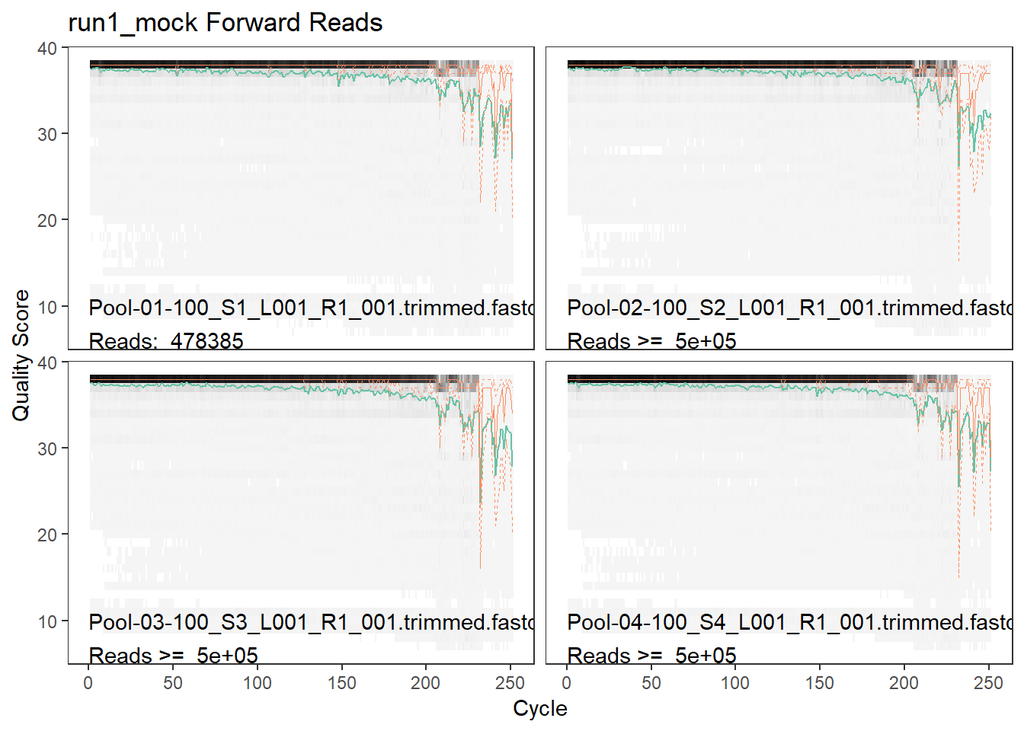

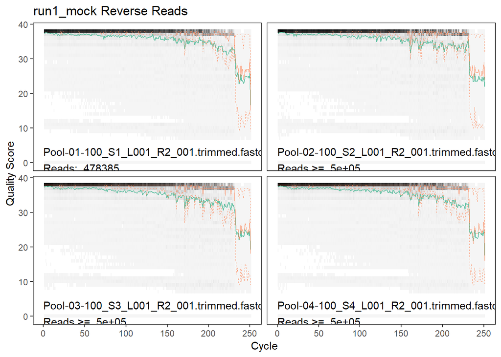

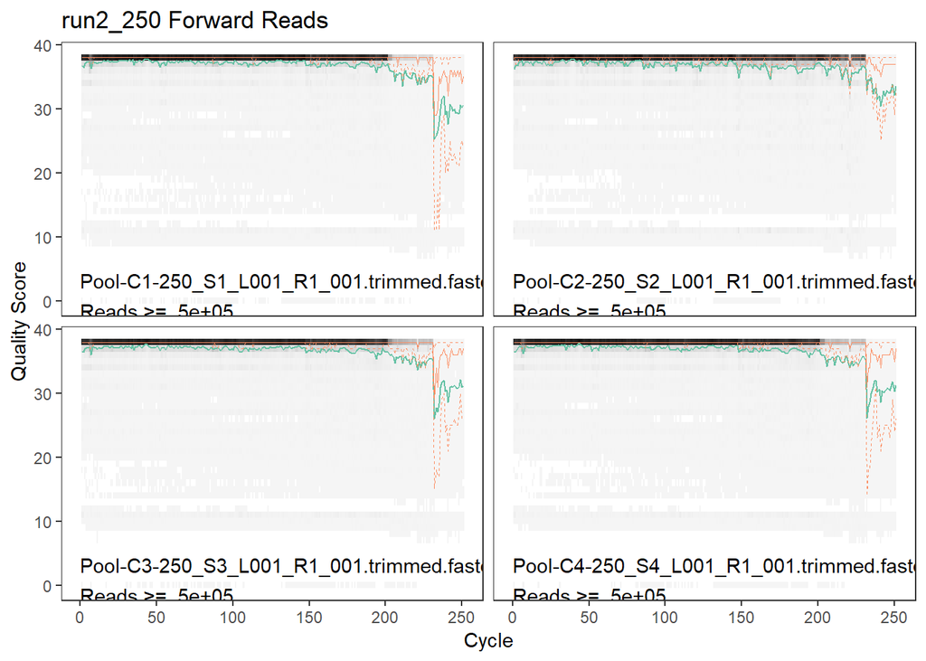

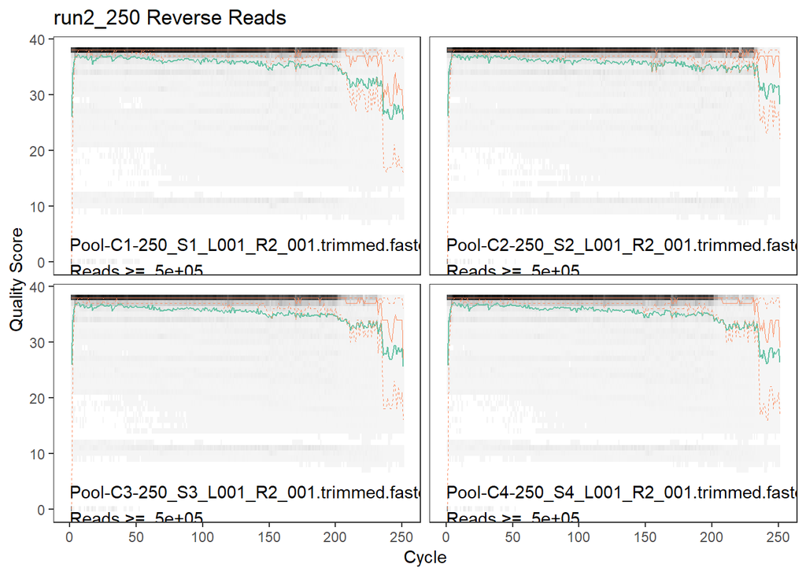

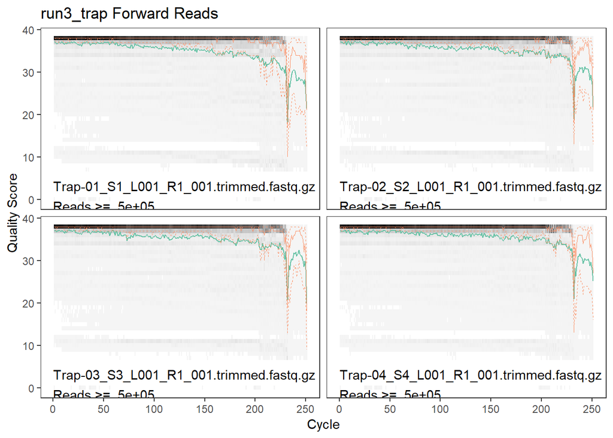

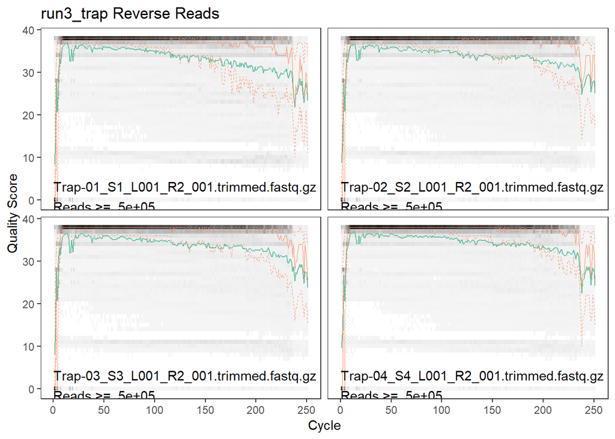

```r
runs <- dir("data/", pattern="run")

for (i in seq(along=runs)){
path <- paste0("data/",runs[i]) # CHANGE ME to the directory containing your demultiplexed forward-read fastq files

fastqFs <- sort(list.files(path, pattern="R1_001.trimmed.fastq.gz", full.names = TRUE))
fastqRs <- sort(list.files(path, pattern="R2_001.trimmed.fastq.gz", full.names = TRUE))
print(plotQualityProfile(fastqFs[1:4]) + ggtitle(paste0(runs[i]," Forward Reads")))
print(plotQualityProfile(fastqRs[1:4]) + ggtitle(paste0(runs[i]," Reverse Reads")))
}
```

In gray-scale is a heat map of the frequency of each quality score at each base position. The median quality score at each position is shown by the green line, and the quartiles of the quality score distribution by the orange lines. The red line shows the scaled proportion of reads that extend to at least that position (this is more useful for other sequencing technologies, as Illumina reads are typically all the same lenghth, hence the flat red line).

# Filter and trim

The forward reads for the hemiptera metabarcoding data are of good quality. Normally it is advised to trim the last few nucleotides to avoid less well-controlled errors that can arise there. The reverse reads are of slightly worse worse quality, especially at the end, which is common in Illumina sequencing. This isn’t too worrisome, as DADA2 incorporates quality information into its error model which makes the algorithm robust to lower quality sequence, but trimming as the average qualities crash will improve the algorithm’s sensitivity to rare sequence variants. Informed by these profiles, reads can be truncated using truncLen=c(forwardlength, reverselength), however in the Hemiptera metabarcoding study there were 3 amplicons of different size generated in a multiplexed PCR, and therefore coarse measures like truncation cannot be applied, as they will impact the 3 amplicons differently. Instead we will use the Truncate quality function (TruncQ=2) to cut the reads at any point the Q score crashes below 2.

```r
##Note - for filtering stage, these parameters may not be optimal for each run or testset, use the previous plotting step to inform this
runs <- dir("data/", pattern="run")
filtered_out <- list()

for (i in seq(along=runs)){
  path <- paste0("data/",runs[i]) # CHANGE ME to the directory containing your demultiplexed forward-read fastq files
  filtpath <- file.path(path, "filtered") # Filtered forward files go into the path/filtered/ subdirectory

  fastqFs <- sort(list.files(path, pattern="R1_001.trimmed.fastq.gz"))
  fastqRs <- sort(list.files(path, pattern="R2_001.trimmed.fastq.gz"))

  if(length(fastqFs) != length(fastqRs)) stop(paste0("Forward and reverse files for ",runs[i]," do not match."))

  filtered_out[[i]] <- (filterAndTrim(fwd=file.path(path, fastqFs), filt=file.path(filtpath, fastqFs),
                                      rev=file.path(path, fastqRs), filt.rev=file.path(filtpath, fastqRs),
                                      maxEE=c(2,5), truncQ=2, maxN = 2, minLen = 100,
                                      rm.phix=TRUE, compress=TRUE, verbose=TRUE))
}
print(filtered_out)
```

## Post filtering error plotting

sanity check to see the effects of the filter and trim step

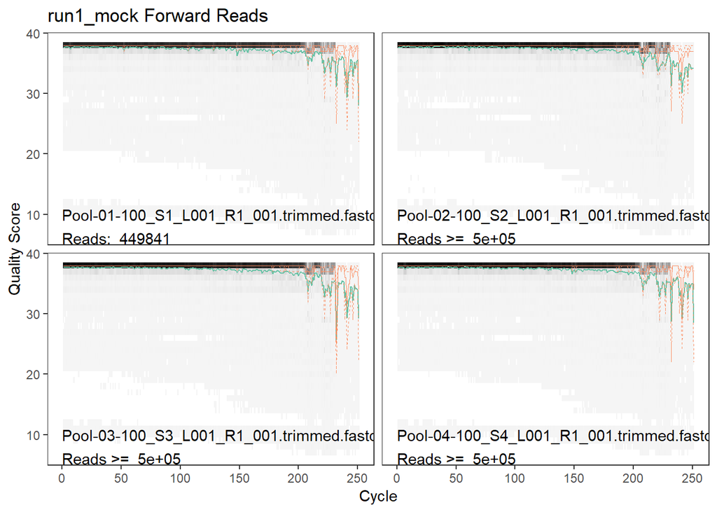

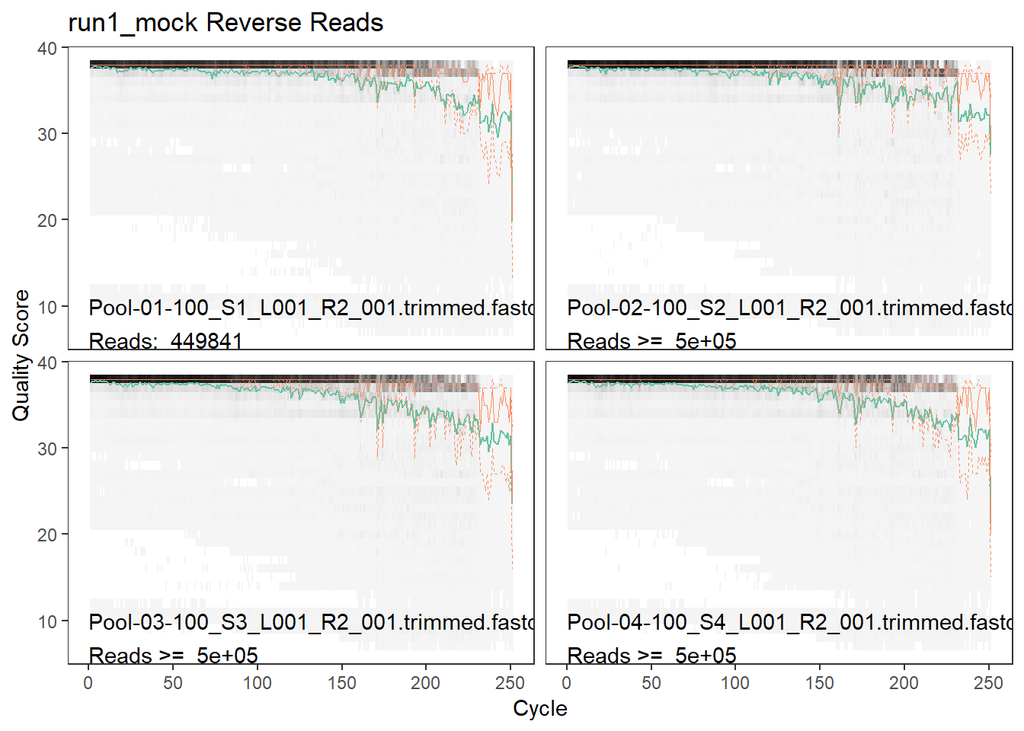

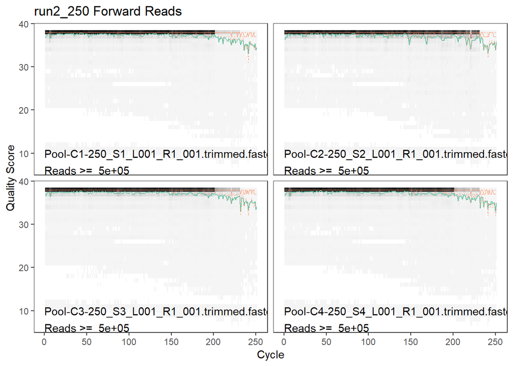

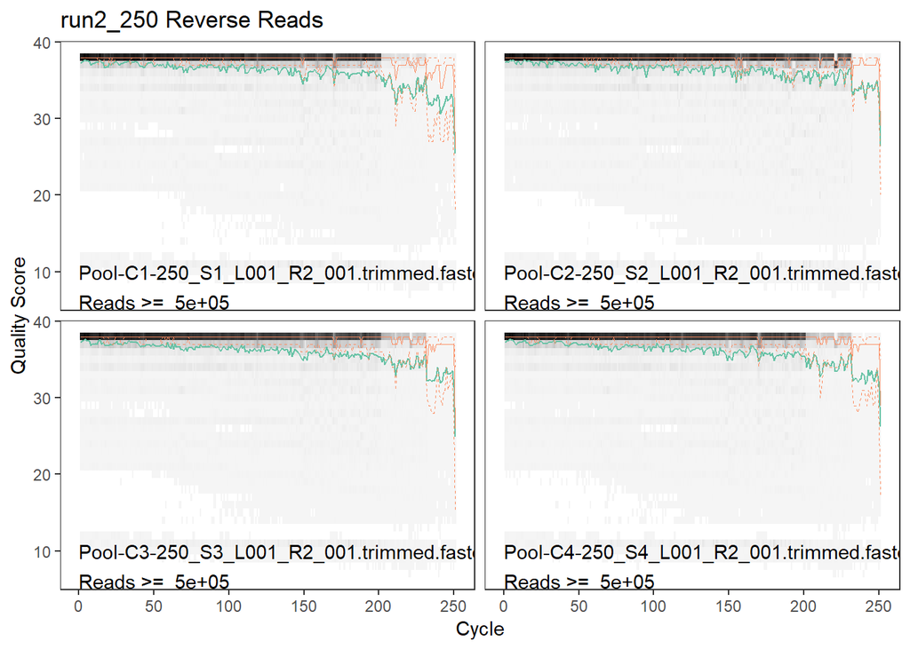

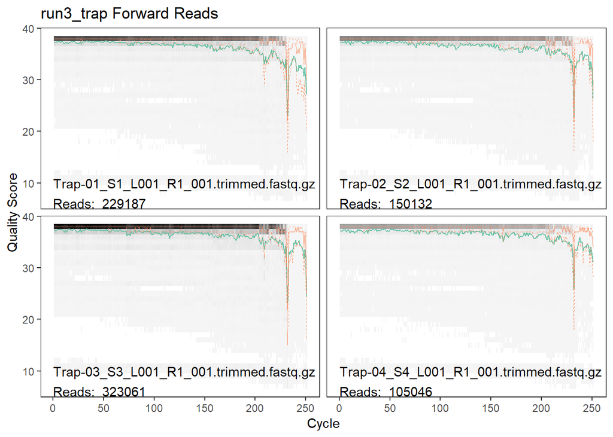

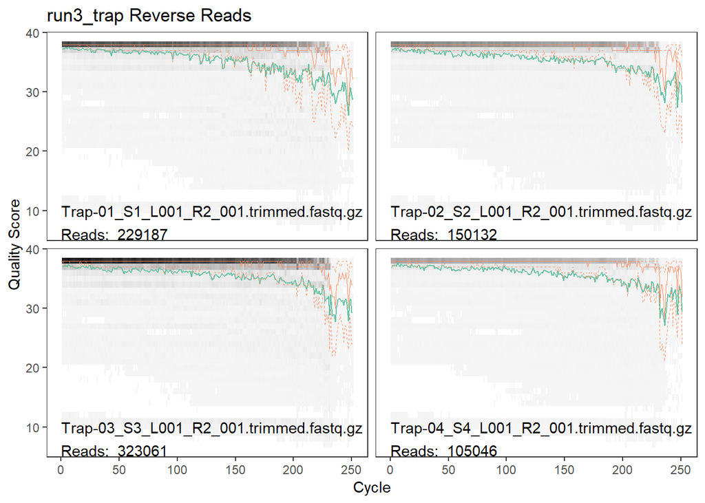

```r
runs <- dir("data/", pattern="run")

##Post filtering plotting
for (i in seq(along=runs)){
  path <- paste0("data/",runs[i]) # CHANGE ME to the directory containing your demultiplexed forward-read fastq files
  filtpath <- file.path(path, "filtered") # Filtered forward files go into the path/filtered/ subdirectory


  filtFs <- sort(list.files(filtpath, pattern="R1_001.trimmed.fastq.gz", full.names = TRUE))
  filtRs <- sort(list.files(filtpath, pattern="R2_001.trimmed.fastq.gz", full.names = TRUE))
  print(plotQualityProfile(filtFs[1:4]) + ggtitle(paste0(runs[i]," Forward Reads")))
  print(plotQualityProfile(filtRs[1:4]) + ggtitle(paste0(runs[i]," Reverse Reads")))
}
```

# Infer sequence variants

Every amplicon dataset has a different set of error rates and the DADA2 algorithm makes use of a parametric error model (err) to model this and infer real biological sequence variation from error. The learnErrors method learns this error model from the data, by alternating estimation of the error rates and inference of sample composition until they converge on a jointly consistent solution. As in many machine-learning problems, the algorithm must begin with an initial guess, for which the maximum possible error rates in this data are used (the error rates if only the most abundant sequence is correct and all the rest are errors).

Following error model learning, the core DADA2 algorthim dereplicates all identical sequencing reads are dereplicated into into “unique sequences” with a corresponding “abundance” equal to the number of reads with that unique sequence. The forward and reverse reads are then merged together by aligning the denoised forward reads with the reverse-complement of the corresponding reverse reads, and then constructing the merged “contig” sequences. By default, merged sequences are only output if the forward and reverse reads overlap by at least **12 bases**, and are identical to each other in the overlap region.

Following this step, a sequence variant table is constructed - a higher-resolution version of the OTU table produced by traditional methods.

In order to handle bigger datasets, in this pipeline the samples are read in and processed within a for-loop, so only one sample is fully loaded into memory at a time. This keeps memory requirements quite low, and multiple MiSeq runs, or a Hiseq lane can be processed on 8GB of memory (although more is nice!).

NOTE: Learning error rates is computationally intensive, as it requires multiple iterations of the core algorithm. Therefore if you are analysing a large dataset you can get the algorithm to only learn from a subset of the reads using (nbases = 1e8, randomize=TRUE) As a rule of thumb, a million 100nt reads (or 100M total bases) is more than adequate to learn the error rates.

```r
runs <- dir("data/", pattern="run")
set.seed(100)

for (i in seq(along=runs)){
  path <- paste0("data/",runs[i]) # CHANGE ME to the directory containing your demultiplexed forward-read fastq files
  filtpath <- file.path(path, "filtered") # Filtered forward files go into the path/filtered/ subdirectory

  filtFs <- list.files(filtpath, pattern="R1_001.trimmed.fastq.gz", full.names = TRUE)
  filtRs <- list.files(filtpath, pattern="R2_001.trimmed.fastq.gz", full.names = TRUE)

  sample.names <- sapply(strsplit(basename(filtFs), "_"), `[`, 1) # Assumes filename = flowcell_samplename_XXX.fastq.gz
  sample.namesR <- sapply(strsplit(basename(filtRs), "_"), `[`, 1) # Assumes filename = flowcell_samplename_XXX.fastq.gz
  if(!identical(sample.names, sample.namesR)) stop("Forward and reverse files from run1 do not match.")
  names(filtFs) <- sample.names
  names(filtRs) <- sample.names

  # Learn error rates from samples
  # nread tells the function how many reads to use in error learning, this can be increased for more accuracy at the expense of runtime

  errF <- learnErrors(filtFs, multithread=TRUE)
  errR <- learnErrors(filtRs, multithread=TRUE)
  ##Print error plots to see how well the algorithm modelled the errors in the different runs
  print(plotErrors(errF, nominalQ=TRUE)+ ggtitle(paste0(runs[i]," Forward Reads")))
  print(plotErrors(errR, nominalQ=TRUE)+ ggtitle(paste0(runs[i]," Reverse Reads")))


  #Error inference and merger of reads
  mergers <- vector("list", length(sample.names))
  names(mergers) <- sample.names
  for(sam in sample.names) {
    cat("Processing:", sam, "\n")
    derepF <- derepFastq(filtFs[[sam]])
    ddF <- dada(derepF, err=errF, multithread=TRUE)

    derepR <- derepFastq(filtRs[[sam]])
    ddR <- dada(derepR, err=errR, multithread=TRUE)
    merger <- mergePairs(ddF, derepF, ddR, derepR) #, maxMismatch = 3
    mergers[[sam]] <- merger
  }


# Construct sequence table
seqtab<- makeSequenceTable(mergers)
saveRDS(seqtab, paste0(path,"/seqtab.rds")) # CHANGE ME to where you want sequence table saved
}
```

[output not shown]

# Merge Runs, Remove Chimeras

```r
runs <- dir("data/", pattern="run")
stlist <- vector()

for (i in seq(along=runs)){
  path <- paste0("data/",runs[i]) # CHANGE ME to the directory containing your demultiplexed forward-read fastq files
  seqs <- list.files(path, pattern="seqtab.rds", full.names = TRUE)

  assign(paste("st", i, sep = ""),readRDS(seqs))
  stlist <- append(stlist, paste("st", i, sep = ""), after=length(seqs))
}

st.all <- mergeSequenceTables(st1, st2, st3)

st.all <- collapseNoMismatch(st.all, minOverlap = 20, orderBy = "abundance",
                                    vec = TRUE, verbose = TRUE)
seqtab.nochim <- removeBimeraDenovo(st.all, method="consensus", multithread=TRUE, verbose=TRUE)

print(paste(sum(seqtab.nochim)/sum(st.all),"of the abundance remaining after chimera removal"))
```

# Assign taxonomy

At this point we will assign kingdom to genus taxonomy to the sequence reads using the RDP classifier, and then add species level taxonomy to this using exact matching

```r
# Assign Kingdom:Genus taxonomy using RDP classifier
tax <- assignTaxonomy(seqtab.nochim, "reference/merged_arthropoda_rdp_genus.fa", multithread=TRUE, minBoot=80, outputBootstraps=FALSE)
colnames(tax) <- c("Kingdom", "Phylum", "Class", "Order", "Family", "Genus")

##add species to taxtable using exact matching
tax_plus <- addSpecies(tax, "reference/merged_arthropoda_rdp_species.fa", allowMultiple=TRUE)

##Add SP. to species rank for those with only a genus rank assignmnet
for(col in seq(7,ncol(tax_plus))) {
  propagate <- is.na(tax_plus[,col]) & !is.na(tax_plus[,col-1])
  tax_plus[propagate,col:ncol(tax_plus)] <-  "spp."
}

##join genus and species name in species rank column
sptrue <- !is.na(tax_plus[,7])
tax_plus[sptrue,7] <- paste(tax_plus[sptrue,6],tax_plus[sptrue,7], sep=" ")

#Check Output
taxa.print <- tax_plus # Removing sequence rownames for display only
rownames(taxa.print) <- NULL
head(taxa.print)

# Write dataset to disk

saveRDS(seqtab.nochim, "data/seqtab_final.rds") # CHANGE ME to where you want sequence table saved
saveRDS(tax_plus, "data/tax_boot80_final.rds") # CHANGE ME ...
```

# Make phyloseq

Following taxonomic assignment, both the sequence table and taxonomic table are passed to the Phyloseq R package for further community analysis and visualisation of data

This involves loading in the sample info csv to merge with the sequence and taxonomy trables

```r
seqtab.nochim <- readRDS("data/seqtab_final.rds") # CHANGE ME to where you want sequence table saved
tax_plus <- readRDS("data/tax_boot80_final.rds") # CHANGE ME ...

#Load sample information
## ---- samdat ----
samdf <- read.csv("sample_data/Sample_info.csv", header=TRUE) ###Change this
#samdf$SampleID <- paste0(samdf$sample_name)
samdf <- samdf[!duplicated(samdf$SampleID),] #Remove duplicate entries for reverse reads

rownames(samdf) <- samdf$SampleID
keep.cols <- c("collection_date", "biome", "target_gene", "feature",
"sample_name" ,"SampleID","experimental_factor")
samdf <- samdf[rownames(seqtab.nochim), keep.cols]

## ---- phyloseq ----
ps <- phyloseq(tax_table(tax_plus), sample_data(samdf),
               otu_table(seqtab.nochim, taxa_are_rows = FALSE))
##save phyloseq object
saveRDS(ps, "data/ps_genus_spp_80.rds")

#Display samDF
head(samdf)
```

```
##             collection_date      biome target_gene   feature sample_name
## Pool-01-100      10/11/2017 Laboratory COI_12s_18s Pool-0100 Pool-01-100
## Pool-02-100      10/11/2017 Laboratory COI_12s_18s Pool-0100 Pool-02-100
## Pool-03-100      10/11/2017 Laboratory COI_12s_18s Pool-0100 Pool-03-100
## Pool-04-100      10/11/2017 Laboratory COI_12s_18s Pool-0100 Pool-04-100
## Pool-05-100      10/11/2017 Laboratory COI_12s_18s Pool-0100 Pool-05-100
## Pool-06-500      10/11/2017 Laboratory COI_12s_18s Pool-0500 Pool-06-500
##                SampleID experimental_factor
## Pool-01-100 Pool-01-100                   O
## Pool-02-100 Pool-02-100                   O
## Pool-03-100 Pool-03-100                   O
## Pool-04-100 Pool-04-100                   O
## Pool-05-100 Pool-05-100                   O
## Pool-06-500 Pool-06-500                   O
```

# Add expected samples

To look at observed vs expected reads for our mock community, we add the expected read tables

This basically loads a dummy sequence table, taxonomy table, and sample data table and merges it into the existing phyloseq object

```r
#Load expected information

exp_seqtab <- as.matrix(read.csv("sample_data/expected/exp_seqtab.csv",row.names=1, header=TRUE))
exp_taxtab <- as.matrix(read.csv("sample_data/expected/exp_taxtab.csv",row.names=1, header=TRUE))
exp_samdf <- read.csv("sample_data/expected/exp_samdf.csv", header=TRUE)

keep.cols <- c("collection_date", "biome", "target_gene", "feature",
"sample_name" ,"SampleID","experimental_factor")
rownames(exp_samdf) <- exp_samdf$SampleID
exp_samdf <- exp_samdf[rownames(exp_seqtab), keep.cols]

## Make phyloseq and merge
ps_exp <- phyloseq(tax_table(exp_taxtab), sample_data(exp_samdf),
               otu_table(exp_seqtab, taxa_are_rows = FALSE))
```

The below is a utility function to enable summarising of Phyloseq objects as easily readable summary tables

```r
fast_melt = function(physeq){
  # supports "naked" otu_table as `physeq` input.
  otutab = as(otu_table(physeq), "matrix")
  if(!taxa_are_rows(physeq)){otutab <- t(otutab)}
  otudt = data.table(otutab, keep.rownames = TRUE)
  setnames(otudt, "rn", "taxaID")
  # Enforce character taxaID key
  otudt[, taxaIDchar := as.character(taxaID)]
  otudt[, taxaID := NULL]
  setnames(otudt, "taxaIDchar", "taxaID")
  # Melt count table
  mdt = melt.data.table(otudt,
                        id.vars = "taxaID",
                        variable.name = "SampleID",
                        value.name = "count")
  # Remove zeroes, NAs
  mdt <- mdt[count > 0][!is.na(count)]
  # Calculate relative abundance
  mdt[, RelativeAbundance := count, by = SampleID]
  if(!is.null(tax_table(physeq, errorIfNULL = FALSE))){
    # If there is a tax_table, join with it. Otherwise, skip this join.
    taxdt = data.table(as(tax_table(physeq, errorIfNULL = TRUE), "matrix"), keep.rownames = TRUE)
    setnames(taxdt, "rn", "taxaID")
    # Enforce character taxaID key
    taxdt[, taxaIDchar := as.character(taxaID)]
    taxdt[, taxaID := NULL]
    setnames(taxdt, "taxaIDchar", "taxaID")
    # Join with tax table
    setkey(taxdt, "taxaID")
    setkey(mdt, "taxaID")
    mdt <- taxdt[mdt]
  }
  return(mdt)
}

summarize_taxa = function(physeq, Rank, GroupBy = NULL){
  Rank <- Rank[1]
  if(!Rank %in% rank_names(physeq)){
    message("The argument to `Rank` was:\n", Rank,
            "\nBut it was not found among taxonomic ranks:\n",
            paste0(rank_names(physeq), collapse = ", "), "\n",
            "Please check the list shown above and try again.")
  }
  if(!is.null(GroupBy)){
    GroupBy <- GroupBy[1]
    if(!GroupBy %in% sample_variables(physeq)){
      message("The argument to `GroupBy` was:\n", GroupBy,
              "\nBut it was not found among sample variables:\n",
              paste0(sample_variables(physeq), collapse = ", "), "\n",
              "Please check the list shown above and try again.")
    }
  }
  # Start with fast melt
  mdt = fast_melt(physeq)
  if(!is.null(GroupBy)){
    # Add the variable indicated in `GroupBy`, if provided.
    sdt = data.table(SampleID = sample_names(physeq),
                     var1 = get_variable(physeq, GroupBy))
    setnames(sdt, "var1", GroupBy)
    # Join
    setkey(sdt, SampleID)
    setkey(mdt, SampleID)
    mdt <- sdt[mdt]
  }
  # Summarize
  summarydt = mdt[, list(totalRA = sum(RelativeAbundance)),
                  by = c(Rank, GroupBy)]
  return(summarydt)
}
```

# Output table of results

```r
##Define transformation functions

#Proportion function
proportions = function(x){
  xprop = (x / sum(x))
  return(xprop)
}
##Transform data to proportions and set low proportions to zero
filterfun = function(x){
  xprop = (x / sum(x)) #Convert to proportions
  xprop[xprop < (1e-4)] <- 0 ## remove taxa under 0.0001, which is 0.01%
  return(xprop)
}

#Subset data to Athropoda only
ps1 = subset_taxa(ps, Phylum == "Arthropoda")

#Export raw data
rawexport <- psmelt(ps1)
write.csv(rawexport, file = "rawarthropod.csv")

#Export proportion data
ps2 <- transform_sample_counts(ps1, fun = proportions)

sum_gen <- summarize_taxa(ps2, "Genus", "SampleID")
sum_gen <- spread(sum_gen, key="SampleID", value="totalRA")
write.csv(sum_gen, file = "allgenes_gen_totalsummary.csv")

sum_sp <- summarize_taxa(ps2, "Species", "SampleID")
sum_sp <- spread(sum_sp, key="SampleID", value="totalRA")
write.csv(sum_sp, file = "allgenes_sp_totalsummary.csv")

#Convert data to proportions and apply filter threshold
psFR <- transform_sample_counts(ps1, fun = filterfun)
psFR <- transform_sample_counts(ps1, fun = proportions)

sum_filt <- summarize_taxa(psFR, "Species", "SampleID")
sum_filt <- spread(sum_filt, key="SampleID", value="totalRA")
write.csv(sum_filt, file = "allgenes_sp_filtsummary.csv")
```

# Plot for all genes merged

All sections below this will be quite specific to the Hemiptera metabarcoding data, however you should be able to get a good idea from this.

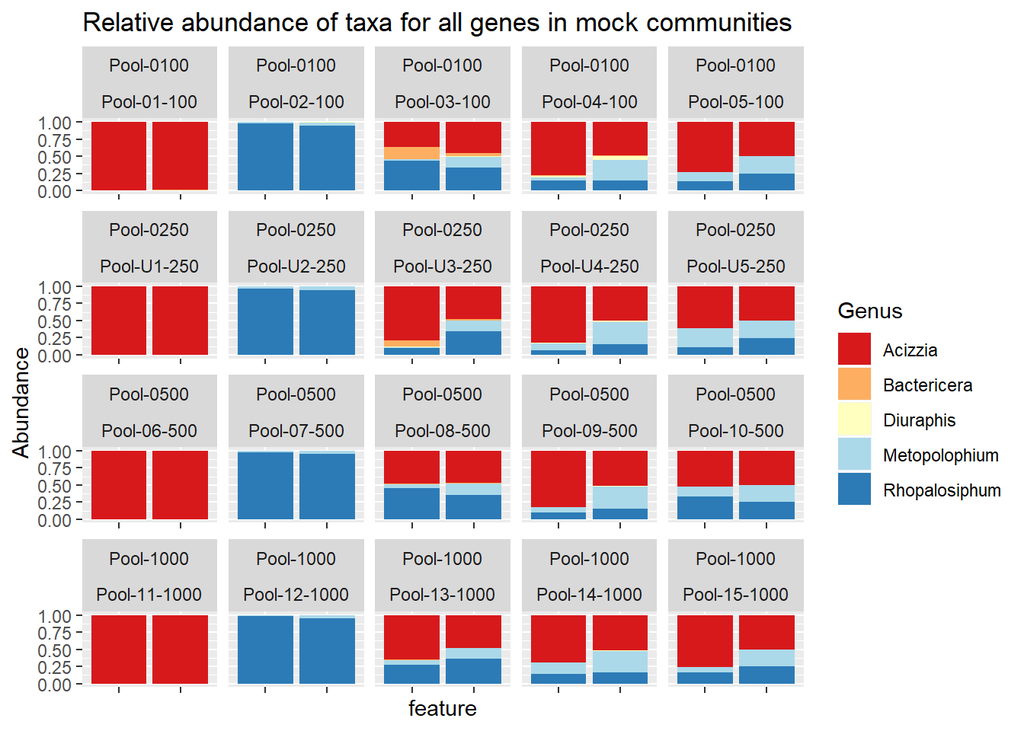

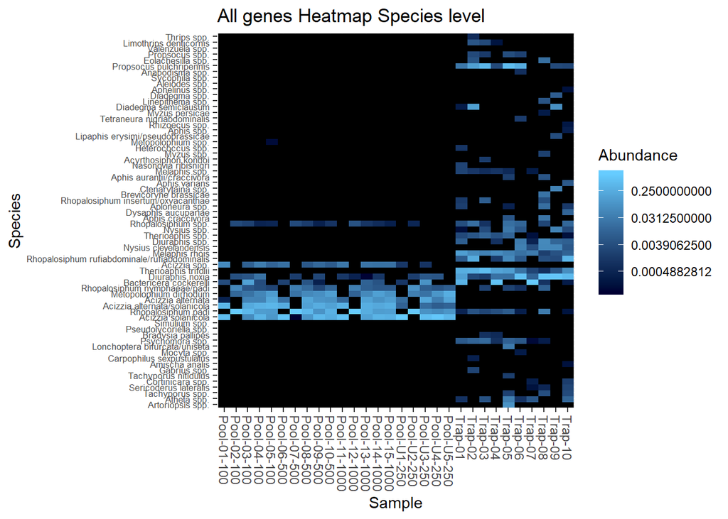

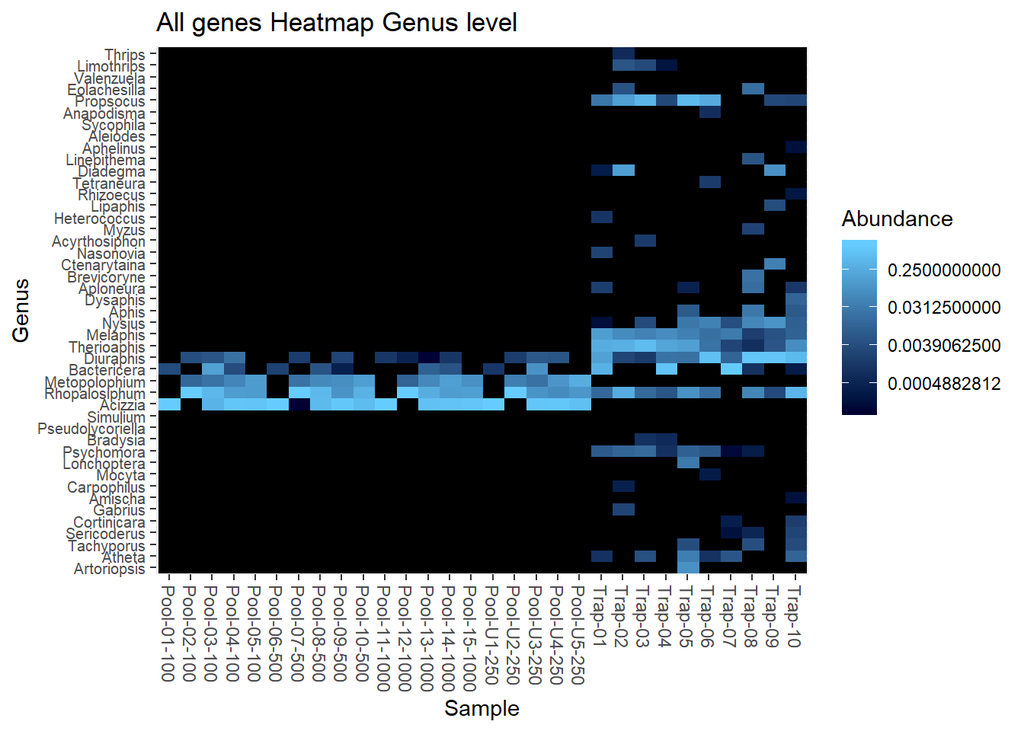

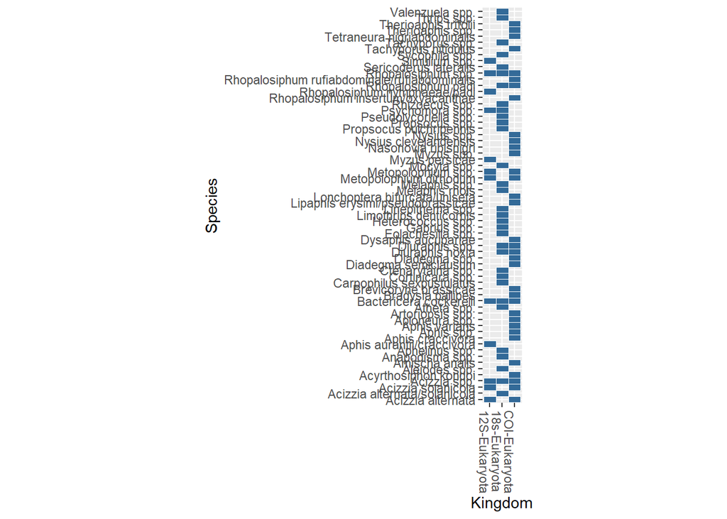

```r
positions = c('Pool-01-100', 'Pool-02-100', 'Pool-03-100', 'Pool-04-100', 'Pool-05-100', 'Pool-06-500', 'Pool-07-500', 'Pool-08-500', 'Pool-09-500', 'Pool-10-500', 'Pool-11-1000', 'Pool-12-1000', 'Pool-13-1000', 'Pool-14-1000', 'Pool-15-1000', 'Pool-U1-250', 'Pool-U2-250', 'Pool-U3-250', 'Pool-U4-250', 'Pool-U5-250', 'Trap-01', 'Trap-02', 'Trap-03', 'Trap-04', 'Trap-05', 'Trap-06', 'Trap-07', 'Trap-08', 'Trap-09', 'Trap-10')

#Merge in expecteds
pstemp <- merge_phyloseq(ps1, ps_exp)
pstemp <- transform_sample_counts(pstemp, fun = filterfun) #Apply filter threhsold


#Drop Kingdom column so we have 3 genes merged
tax_table(pstemp) <- tax_table(pstemp)[,2:7]


#export <- psmelt(psFR)
#write.csv(export, file = "filtered.csv")

##Plot mock communties
psmock = subset_samples(pstemp, biome == "Laboratory")
psmock = filter_taxa(psmock, function(x) mean(x) > 0, TRUE)
rm_c1 <-  c("Pool-C1-250","Pool-C2-250","Pool-C3-250","Pool-C4-250","Pool-C5-250")
psmock <- subset_samples(psmock, sample_names(psmock)!=rm_c1)
rm_c1_exp<- c("Pool-C1-250-exp","Pool-C2-250-exp","Pool-C3-250-exp","Pool-C4-250-exp","Pool-C5-250-exp")
psmock <- subset_samples(psmock, sample_names(psmock)!=rm_c1_exp)
psmock = tax_glom(psmock, "Species", NArm = TRUE)
psmock <- transform_sample_counts(psmock, fun= proportions) # Reset scale to 1 following NArm

mdf <- psmelt(psmock)
p <- ggplot(mdf, aes_string(x= "SampleID", y="Abundance", fill= "Genus" ))
p = p + geom_bar(stat = "identity", position = "stack", color = "NA")
p = p + theme(axis.text.x = element_text(angle = -90, hjust = 0))
p = p + ggtitle(paste0("Relative abundance of taxa for all genes in mock communities"))
p = p + xlab("Mock Community")
p = p + scale_fill_brewer(type="div", palette="RdYlBu")
p1 = p + facet_wrap(feature~sample_name, drop=TRUE, scales="free_x") + xlab("feature")+ theme(axis.text.x = element_blank())

psreal = subset_samples(pstemp, experimental_factor != "Exp")
psreal <- subset_samples(psreal, sample_names(psreal)!=rm_c1)

psglom = tax_glom(psreal, "Species", NArm = TRUE)
psglom <- transform_sample_counts(psglom, fun= proportions) # Reset scale to 1 following NArm
p2 <- plot_heatmap(psglom, "NMDS", "bray", taxa.label="Species", title= paste0("All genes Heatmap Species level"), taxa.order="Order", trans=log_trans(2)) + scale_x_discrete(limits = positions)


psglom2 = tax_glom(psreal, "Genus", NArm = TRUE)
psglom2 <- transform_sample_counts(psglom2, fun= proportions) # Reset scale to 1 following NArm
p3 <- plot_heatmap(psglom2, "NMDS", "bray", taxa.label="Genus", title= paste0("All genes Heatmap Genus level"), taxa.order="Order", trans=log_trans(2)) + scale_x_discrete(limits = positions)

##Presence absense for each gene

mdt = fast_melt(psFR)
# Add the variable indicated in `GroupBy`, if provided.
    sdt = data.table(SampleID = sample_names(psFR),
                     var1 = get_variable(psFR, "SampleID"))
    setnames(sdt, "var1", "SampleID")
    # Join
    setkey(sdt, SampleID)
    setkey(mdt, SampleID)
    mdt <- sdt[mdt]
  # Summarize
  summarydt = mdt[, list(totalRA = sum(RelativeAbundance)),
                  by = c("Kingdom","Order","Family", "Genus","Species", "SampleID", "taxaID")]
  summarydt <- summarydt[!is.na(summarydt$Species)]
  summarydt$totalRA[summarydt$totalRA > 0] <- 1

  summarydt$totalRA <- replace(summarydt$totalRA,summarydt > 0, 1)
  summarydt$test <- paste(summarydt$Order,summarydt$Family,summarydt$Species,sep="_")

p4 <- ggplot(summarydt, aes(Kingdom, Species)) + geom_tile(aes(fill = totalRA),
   colour = "White") + theme(legend.position="none") + coord_fixed(ratio=.5) + theme(axis.text.x = element_text(angle = -90, hjust = 0))


p1
p2
p3
p4

pdf(file= "allgenes_plots.pdf", paper="a4")
plot(p1)
plot(p2)
plot(p3)
plot(p4)
dev.off()
```

# Plot each gene seperately

```r
positions = c('Pool-01-100', 'Pool-02-100', 'Pool-03-100', 'Pool-04-100', 'Pool-05-100', 'Pool-06-500', 'Pool-07-500', 'Pool-08-500', 'Pool-09-500', 'Pool-10-500', 'Pool-11-1000', 'Pool-12-1000', 'Pool-13-1000', 'Pool-14-1000', 'Pool-15-1000', 'Pool-U1-250', 'Pool-U2-250', 'Pool-U3-250', 'Pool-U4-250', 'Pool-U5-250', 'Trap-01', 'Trap-02', 'Trap-03', 'Trap-04', 'Trap-05', 'Trap-06', 'Trap-07', 'Trap-08', 'Trap-09', 'Trap-10')

genes <- unique(psmelt(ps) %>% select(Kingdom))
genes <- as.vector(genes$Kingdom)
genes <- genes[!is.na(genes)]

for (i in seq(along=genes)){
  ####PROBLEM HERE WILL BE THE MOCKS!
print(genes[i])
ps_gene = subset_taxa(ps, Kingdom == genes[i])
ps_gene = subset_taxa(ps_gene, Phylum == "Arthropoda")

ps_genexp <- merge_phyloseq(ps_gene, ps_exp)
tax_table(ps_genexp) <- tax_table(ps_genexp)[,2:7]

#Summary export
summary <-  subset_samples(ps_genexp, experimental_factor == "O")
gen_summary <- summarize_taxa(summary, "Genus", "SampleID")
gen_summary <- spread(gen_summary, key="SampleID", value="totalRA")
write.csv(gen_summary, file = paste0(genes[i],"_gen_summary.csv"))
sp_summary <- summarize_taxa(summary, "Species", "SampleID")
sp_summary <- spread(sp_summary, key="SampleID", value="totalRA")
write.csv(sp_summary, file = paste0(genes[i],"_sp_summary.csv"))

##Transform data to proportions and set low proportions to zero - NEEDED TO REMOVE INDEX SWITCHING

psra_gene <- transform_sample_counts(ps_genexp, fun = filterfun)
##Remove zero counts
psra_gene = filter_taxa(psra_gene, function(x) mean(x) > 0, TRUE) #Used to be 1e-6

##Figure  1 - Mock communities

##Plot mock communties
psmock_gene = subset_samples(psra_gene, biome == "Laboratory")
psmock_gene = filter_taxa(psmock_gene, function(x) mean(x) > 0, TRUE)
rm_c1 <-  c("Pool-C1-250","Pool-C2-250","Pool-C3-250","Pool-C4-250","Pool-C5-250")
psmock_gene <- subset_samples(psmock_gene, sample_names(psmock_gene)!=rm_c1)
rm_c1_exp<- c("Pool-C1-250-exp","Pool-C2-250-exp","Pool-C3-250-exp","Pool-C4-250-exp","Pool-C5-250-exp")
psmock_gene <- subset_samples(psmock_gene, sample_names(psmock_gene)!=rm_c1_exp)
psmock_gene = tax_glom(psmock_gene, "Species", NArm = TRUE)
psmock_gene <- transform_sample_counts(psmock_gene, fun= proportions) # Reset scale to 1 following NArm


mdf <- psmelt(psmock_gene)
p <- ggplot(mdf, aes_string(x= "SampleID", y="Abundance", fill= "Genus" ))
p = p + geom_bar(stat = "identity", position = "stack", color = "NA")
p = p + theme(axis.text.x = element_text(angle = -90, hjust = 0))
p = p + ggtitle(paste0("Relative abundance of taxa for ", genes[i], " in mock communities"))
p = p + xlab("Mock Community")
p = p + scale_fill_brewer(type="div", palette="RdYlBu")
p1 = p + facet_wrap(feature~sample_name, drop=TRUE, scales="free_x") + xlab("feature")+ theme(axis.text.x = element_blank())

psreal_gene = subset_samples(psra_gene, experimental_factor != "Exp")
psreal_gene <- subset_samples(psreal_gene, sample_names(psreal_gene)!=rm_c1)

psglom = tax_glom(psreal_gene, "Species", NArm = TRUE)
p2 <- plot_heatmap(psglom, "NMDS", "bray", taxa.label="Species", title= paste0(genes[i]," Heatmap Species level"), taxa.order="Order", trans=log_trans(2)) + scale_x_discrete(limits = positions)

psglom2 = tax_glom(psreal_gene, "Genus", NArm = TRUE)
p3 <- plot_heatmap(psglom2, "NMDS", "bray", taxa.label="Genus", title= paste0(genes[i]," Heatmap Genus level"), taxa.order="Order", trans=log_trans(2)) + scale_x_discrete(limits = positions)

pdf(file= paste0(genes[i],"_plots.pdf"), paper="a4")
plot(p1)
plot(p2)
plot(p3)
dev.off()
}
```

# Krona chart

Krona (https://github.com/marbl/Krona/wiki) allows hierarchical data, such as the results of taxonomic assignment, to be explored with zooming, multi-layered pie charts.

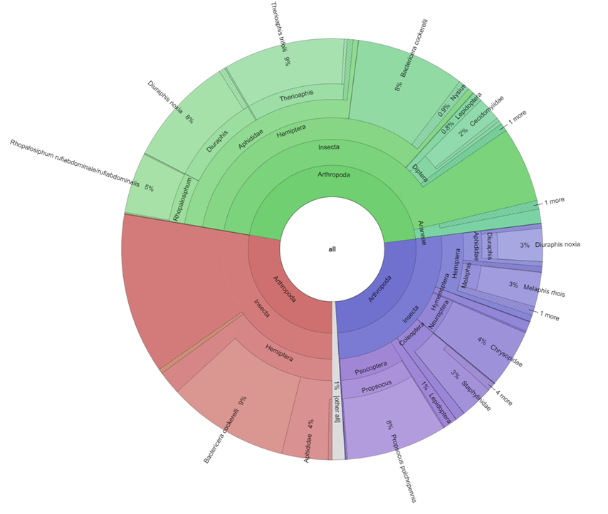

Krona Plot

```r
##Krona charts currently require unix OS

plot_krona(psFR,"Per_trap_krona", "SampleID",trim=T)# Krona seperated by trap
plot_krona(psFR,"All_trap_krona", "biome",trim=T) # Krona seperated by mock or real
```